# Exploration of real bulk RNA-seq datasets

ReCount data for CHD8 regulatory network (SRP047233)

Yuqing Zhang

2018-11-01

## Introduction

ReCount is a public database of pre-processed RNA-seq gene count data (Collado-Torres et al. 2017). The SVAseq paper (Leek 2014) used 2 studies from ReCount with gene measurements in two separate Hapmap populations, and looked for differentially expressed genes between genders in the two studies combined. However, the sample information for the Hapmap dataset is no longer available as NCBI took down Hapmap (https://www.ncbi.nlm.nih.gov/variation/news/NCBI_retiring_HapMap/).

Here, I searched the ReCount database with the keyword “batch”, and found a few datasets with abstracts containing this word (which means that the dataset potentially has batch effect). One of them is SRP047233 (Sugathan et al. 2014). This dataset aims to investigate the impact of decreased CHD8 expression on the expression of genes in downstream (CHD8-regulated) network. Truncating mutation of CHD8 is an important risk factor for autism spectrum disorder (ASD).

### Overall design

RNA-seq in NPCs treated with shRNAs targeting CHD8. For controls, NPCs were treated with shRNAs targeting GFP and LacZ. Infection and sequencing was carried out in 2 separate batches, with one GFP and one LacZ sample in each batch. All samples were sequenced in two technical replicates. (https://trace.ncbi.nlm.nih.gov/Traces/sra/?study=SRP047233)

### Download data & summarize basic info

First, we download the data using the recount R package as shown in its vignette. Note that we use the read_counts() function instead of scale_counts() to convert the provided base pair counts to read counts, so that we get the raw counts without normalization.

After downloading the data, we calculate a few basic statistics of the dataset.

```
######  Samples  #######
- Total number of samples:
[1] 54

- Number of samples in condition groups:
group
CHD8  GFP LacZ
  34   10   10

- Number of samples in batches:
batch
 1  2
30 24
In batch 1:
CHD8  GFP LacZ
  18    6    6
In batch 2:
CHD8  GFP LacZ
  16    4    4


######  Genes  #######
- Total number of genes:
[1] 58037

- Number of genes with 0 counts:
37177 64.1%

- Number of genes with maximum 10 counts:
33746 58.1%

- Number of genes with ONLY 0s:
11976 20.6%


######  Counts  #######
- Range of count in whole dataset:
[1]      0 390200

- Average count in whole dataset:
[1] "Mean: 291.246"
[1] "Median: 1"
```

For the following analysis, **we remove genes with only zero values across all samples**.

```r
## Remove genes with all 0 counts
rse_gene <- rse_gene[apply(assay(rse_gene, "counts"), 1, function(x){!all(x==0)}), ]
print(dim(rse_gene))
```

```
[1] 46061    54
```

The figure below shows distribution of percentages of zero counts for the remaining genes (each data point represents a gene, i.e., how many zeros are there in each gene).

```
######  Proportion of genes with X% zeros across samples  #######
 <10.0%  <20.0%  <30.0%  <40.0%  <50.0%  <60.0%  <70.0%  <80.0%  <90.0% <100.0%
  0.525   0.035   0.034   0.027   0.032   0.030   0.033   0.049   0.062   0.172
```

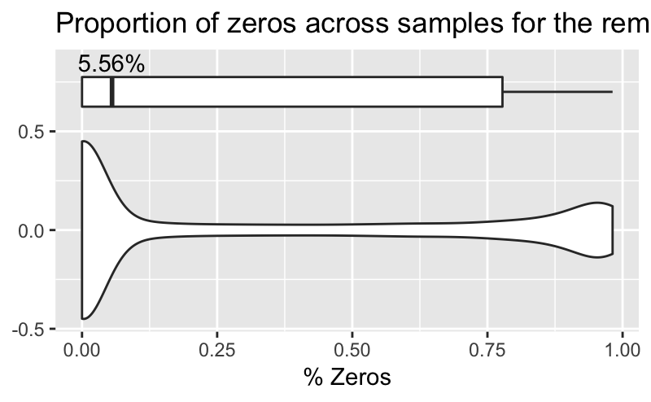

## Existence of batch effect

We first visualize the data using PCA and hierarchical clustering, to see if there is any batch effect in the dataset. Based on these plots, I believe there exists a certain level of batch effect in the data, as samples cluster more by batch than by biological condition.

### PCA

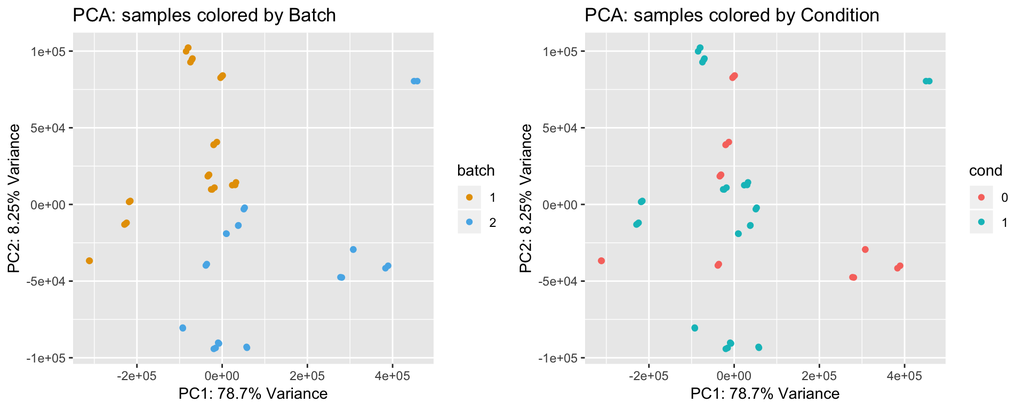

### Dendrograms

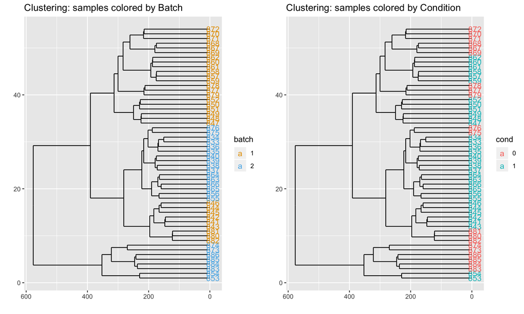

## Library size

Next, we take a look at the observed library sizes of samples, and to see if there is a difference in library size across batches.

```
Range of observed library sizes across samples:
[1] "4.14e+06" "3.15e+07"
```

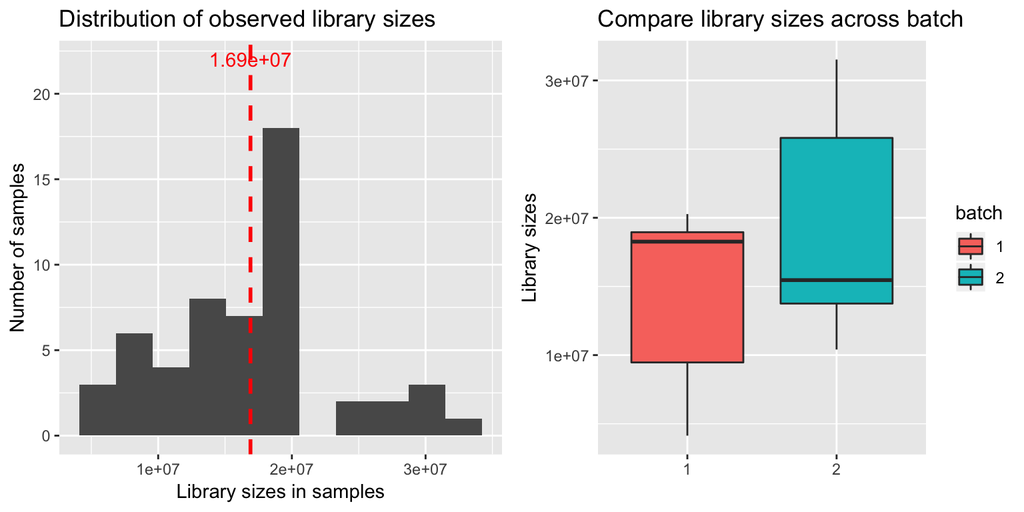

## Gene expression distribution

Our next step is to interrogate the gene expression distributions.

We first simply plot the counts, CPM, and log2CPM of 20 randomly chosen genes in the dataset. These figures are stored under directory specified by output_dir.

### Fold changes in mean

We then use edgeR to perform differential expression analysis, and calculate (log-) fold changes of all genes between condition groups and batches.

#### Change WRT condition

To rule out the impact of batch effect, we limit our DE analysis with regard to biological condition in one of the batches. Here we specify the batch to be **Batch 1** due to a larger batch size.

```r
####  Differential genes relative to biological condition
####  (within batch 1 / batch specified by 'test_batch')
test_batch <- 1
counts_batch <- assay(rse_gene,"counts")[, batch==test_batch]
cond_batch <- group_num[batch==test_batch]
y <- DGEList(counts=counts_batch, group=as.factor(cond_batch))
y <- calcNormFactors(y, method="TMM")
design <- model.matrix(~as.factor(cond_batch))
y <- estimateDisp(y, design)
fit <- glmQLFit(y, design)
qlf <- glmQLFTest(fit, coef=2)
de_res <- topTags(qlf, n=nrow(rse_gene))

up_genes <- rownames(de_res)[de_res$table$logFC >= 0]  # all up-regulated genes (descending order in terms of p value)
head_up_genes <- head(up_genes, n=50)  # top-50 significant up-regulated genes
tail_up_genes <- tail(up_genes, n=50)  # 50 least significant up-regulated genes
cond_up_inds <- up_genes
down_genes <- rownames(de_res)[de_res$table$logFC < 0]  # all down-regulated genes
head_down_genes <- head(down_genes, n=50)  # top-50 significant down-regulated genes
tail_down_genes <- tail(down_genes, n=50)  # 50 least significant down-regulated genes
cond_down_inds <- down_genes
```

```
######  Changes in terms of average gene counts  ######
         top50 up top50 down 100 least DE
Controls    233.3      713.4         97.2
Cases       516.9      365.6        104.2

######  Range of fold change across biological conditions  ######
          top50 up top50 down 100 least DE
min FC       1.811      0.009        0.925
median FC    2.916      0.342        1.000
mean FC      7.115      0.338        0.997
max FC      75.489      0.623        1.000

######  Range of Log(fold change) across biological conditions  ######
             top50 up top50 down 100 least DE
min logFC       0.594     -4.692       -0.078
median logFC    1.070     -1.074        0.000
mean logFC      1.962     -1.084       -0.003
max logFC       4.324     -0.473        0.000
```

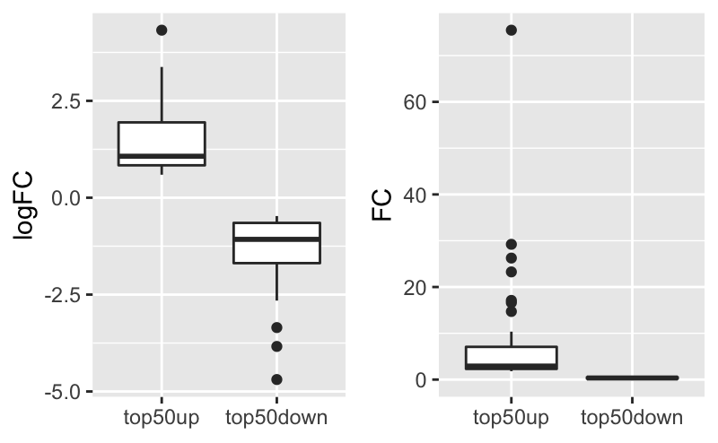

**Conclusions:**

- Biological fold change comparing average counts **in top DE genes** is about 2-2.2.
- Gene-wise fold change of **top DE genes** has a wide range (median 3, mean 7).

#### Change WRT batch

We are also interested to see how the average (mean) gene counts change across batches (i.e. **degree of mean batch effect**).

To explore this mean batch effect, we **first perform DE with regard to the batch variable**. To rule out the impact of biological condition, we perform this analysis within **control** samples only. Note that this DE is not true DE - it’s testing if there is a significant mean difference between two batches. Some genes will not be different in mean, while some will. Which means that batch doesn’t affect all genes in the same way.

```r
####  Differential genes relative to batch
####  (within condition 0 / condition specified by 'test_cond')
test_cond <- 0
counts_cond <- assay(rse_gene,"counts")[, group_num==test_cond]
batch_cond <- batch[group_num==test_cond]
y <- DGEList(counts=counts_cond, group=as.factor(batch_cond))
y <- calcNormFactors(y, method="TMM")
design <- model.matrix(~as.factor(batch_cond))
y <- estimateDisp(y, design)
fit <- glmQLFit(y, design)
qlf <- glmQLFTest(fit, coef=2)
de_res <- topTags(qlf, n=nrow(rse_gene))
up_genes <- rownames(de_res)[de_res$table$logFC >= 0]  # all up-regulated genes
head_up_genes <- head(up_genes, n=50)  # top-50 up-regulated genes
tail_up_genes <- tail(up_genes, n=50)  # 50 least up-regulated genes
batch_up_inds <- up_genes
down_genes <- rownames(de_res)[de_res$table$logFC < 0]  # all down-regulated genes
head_down_genes <- head(down_genes, n=50)  # top-50 down-regulated genes
tail_down_genes <- tail(down_genes, n=50)  # 50 least down-regulated genes
batch_down_inds <- down_genes
```

```
######  Batch differences in terms of mean gene counts  ######
       top50 up top50 down 100 least changed
Batch1   335.15     845.83             44.23
Batch2  1325.03     461.23             70.65

######  Range of fold change between batches  ######
- All genes - FC:
0.001 2532.594

- All genes - log(FC):
-6.881 7.837

- Top genes - FC:
          top50 up top50 down 100 least DE
min FC       1.935      0.001        0.956
median FC    4.780      0.100        1.000
mean FC     23.853      0.143        0.998
max FC     461.897      0.525        1.000

- Top genes - log(FC):
             top50 up top50 down 100 least DE
min logFC       0.660     -6.595       -0.045
median logFC    1.564     -2.301        0.000
mean logFC      3.172     -1.942       -0.002
max logFC       6.135     -0.645        0.000
```

### Batch mean

**Median (of all genes)** gene-wise mean across all batches:

```
         Batch1 Batch2
Controls   3.50   5.88
Cases      3.83   3.31
```

Scaled by that of batch 1:

```
         Batch1 Batch2
Controls      1   1.68
Cases         1   0.86
```

### Batch dispersion

Aside from average gene counts, we are interested in comparing dispersions in the two batches. **Difference in the dispersions across batches suggests variance batch effect not specified by Poisson model**. We visualize the gene-wise dispersion estimates from edgeR:

```
####  Statistics about dispersion estimates from the two batches  ####
              Batch1 Batch2
min disp.     0.0001 0.0001
median disp.  0.0702 0.0099
mean disp.    0.1587 0.0598
max disp.    12.1763 9.7571
```

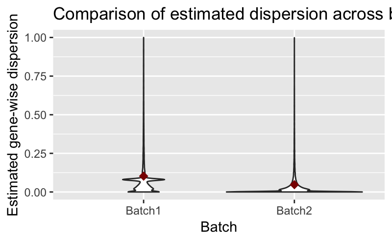

**Conclusions:**

- Mean dispersion in Batch 1 is about 3 times of those in Batch 2.
- We see huge gene-wise dispersions, possibly caused by 0 counts.

### Batch variance

**Median (of all genes)** gene-wise variance:

```
         Batch1 Batch2
Controls   6.52   7.64
Cases      5.83   4.40
```

Scaled by that of batch 1:

```
         Batch1 Batch2
Controls      1   1.17
Cases         1   0.75
```

## Impact of 0 counts on gene distributions

We have seen above that over half of genes in the dataset contain some portions of zeros. Having 0 counts can have a good impact on mean and dispersion estimation. We evaluate such impact in this section, and see how NB distribution fits to non-zero portion of genes. We first take the non-zero portion of the genes.

### Fold change in mean in non-zero portion

#### Change WRT condition in batch 1

Within **batch 1**, we compare mean (here refers to non-zero mean) across biological condition groups. Specifically, **we saved the previous DE analysis results using edgeR, on counts containing zeros**. We call all genes with $\log(FC) >= 0$ as “up” genes, and $\log(FC) < 0$ as “down” genes. The top 50 “up” and “down” genes are still determined by the previous DE containing zeros.

```
######  Changes in MEAN non-zero gene counts  ######
         top50 up top50 down 100 least DE
Controls    235.7      714.6        223.0
Cases       516.9      375.2        234.5
```

```
######  Changes in MEDIAN non-zero gene counts  ######
         top50 up top50 down 100 least DE
Controls    132.5        307           27
Cases       327.0        283           29
```

**Conclusions:**

- Biological fold change (in non-zero portion) comparing average counts **in top genes** is about 1.9-2.2 (mean), 1.1-2.5 (median).**
- O counts did not strongly affect biological signal in terms of average counts **in top genes**.

#### Change WRT batch in control samples

Similarly, we compare non-zero mean **in top genes** across batches within control samples. Here “top genes” refer to top gene lists from previous DE within control samples comparing batches.

```
######  Changes in MEAN non-zero gene counts  ######
        top50 up top50 down 100 least DE
Batch 1    343.7      845.8        100.5
Batch 2   1325.0      479.2        147.2
```

```
######  Changes in MEDIAN non-zero gene counts  ######
        top50 up top50 down 100 least DE
Batch 1    152.0      243.5            6
Batch 2    893.5       88.0            8
```

**Conclusions:**

- Mean batch effect fold change (non-zero portion) comparing average counts **in top genes** ranges from 1.5-3.9 (mean), 1.33-5.9 (median).
- O counts did not strongly affect mean batch effect in terms of average counts **in top genes**.

### Batch mean with 0 counts removed

**Median (of all genes)** gene-wise mean after removing zeros:

```
         Batch1 Batch2
Controls   8.64  13.25
Cases      7.25   7.50
```

Scaled by that of batch 1:

```
         Batch1 Batch2
Controls      1   1.53
Cases         1   1.03
```

### Batch dispersion with 0 counts removed

Dispersion estimates are more likely impacted by 0 counts. We re-estimate the dispersions in each batch, using non-zero portion of each gene. Then we compare the dispersion estimates across batches.

```
####  Statistics about dispersion estimates (from NON-ZERO portions) from the two batches  ####
             Batch1 Batch2
min disp.    0.0000 0.0000
median disp. 0.1781 0.0912
mean disp.   0.1737 0.1088
max disp.    1.9272 2.4620
```

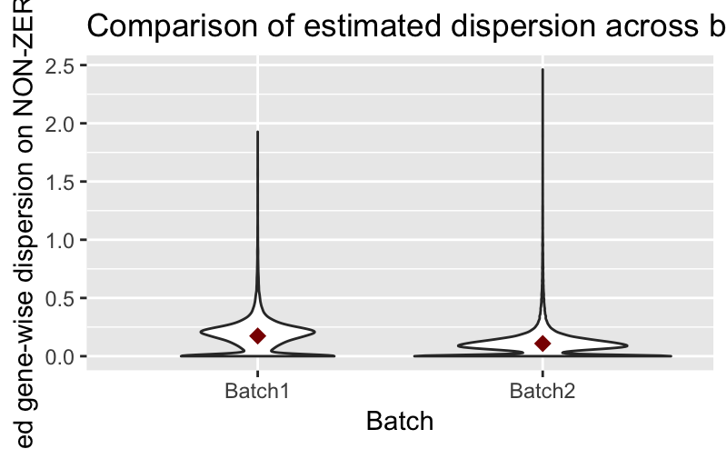

**Conclusions:**

### Batch variance with 0 counts removed

**Median (of all genes)** gene-wise variance after removing zeros:

```
         Batch1 Batch2
Controls  53.17  71.84
Cases     34.87  39.93
```

Scaled by that of batch 1:

```
         Batch1 Batch2
Controls      1   1.35
Cases         1   1.15
```

### Is there a difference in zero portions across batches?

Another question related to batch effect, is whether there is any difference in the percentage of 0 counts in a gene between two batches.

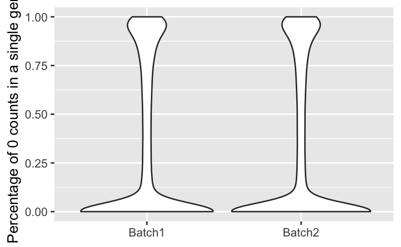

**Conclusions:**

- There isn’t an obvious difference in zero fractions between batches.

### Goodness of fit for NB distribution to non-zero portion of genes

It is difficult to evaluate quantitatively the goodness-of-fit of NB distribution on data. Instead, we generate Q-Q plots for 100 randomly selected genes, comparing data with NB distribution using ML estimated parameters. We generate these plots **within batch 1, for cases and control samples separately**. Figures are stored under {output_dir}/qqplots/.

## More justification for having different dispersion parameter for different batches

Finally, a very important assumption of ComBat-seq model (compared to adding batch covariates in linear model of edgeR and DESeq), is that **having a different dispersion parameter for each batch is beneficial for DE performance**. As argued by many of these papers, accurate estimation of dispersion paramters are important for DE detection. As we have seen above, there is some difference in dispersion distribution across batches. If dispersion estimates within each batch and using the whole study are not consistent with each other, then it is justification that we may need different dipsersion parameter for different batches, and it could be good for DE.

Here we generate scatter plots comparing dispersion estimates within each batch to estimates from whole dataset (**including batch as a covariate in whole study**).

### Gene-wise dispersion estimates (log10 scale)

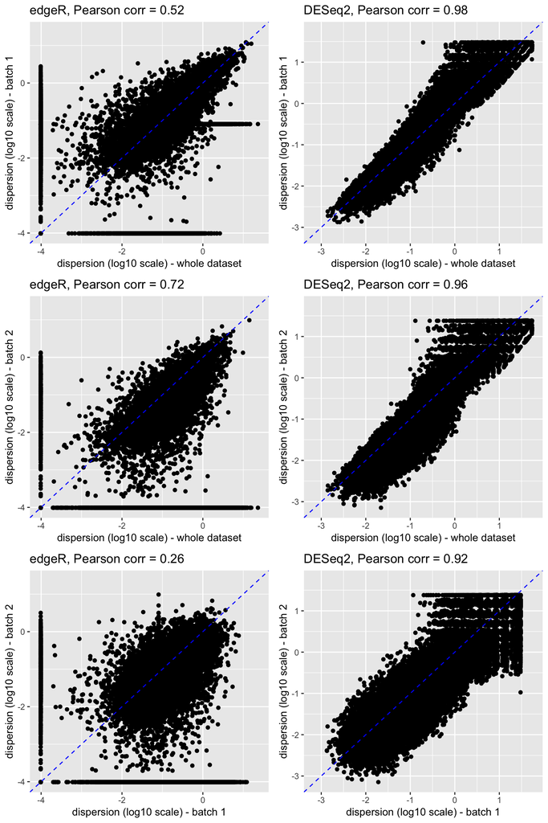

### Trended dispersion estimates (log10 scale)

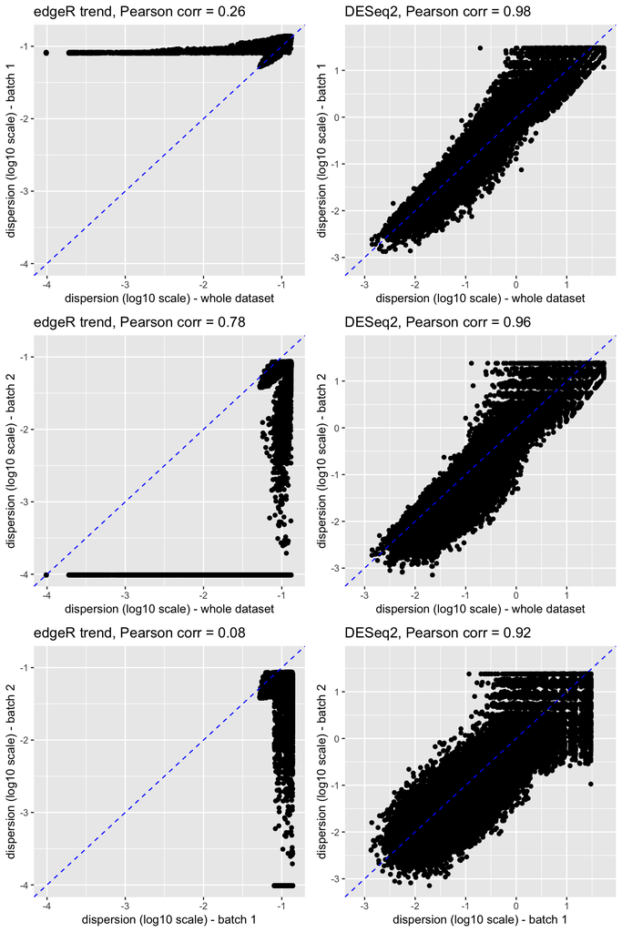

## References

Collado-Torres, Leonardo, Abhinav Nellore, Kai Kammers, Shannon E Ellis, Margaret A Taub, Kasper D Hansen, Andrew E Jaffe, Ben Langmead, and Jeffrey T Leek. 2017. “Reproducible Rna-Seq Analysis Using Recount2.” *Nature Biotechnology* 35 (4). Nature Publishing Group: 319.

Leek, Jeffrey T. 2014. “Svaseq: Removing Batch Effects and Other Unwanted Noise from Sequencing Data.” *Nucleic Acids Research* 42 (21). Oxford University Press: e161–e161.

Sugathan, Aarathi, Marta Biagioli, Christelle Golzio, Serkan Erdin, Ian Blumenthal, Poornima Manavalan, Ashok Ragavendran, et al. 2014. “CHD8 Regulates Neurodevelopmental Pathways Associated with Autism Spectrum Disorder in Neural Progenitors.” *Proceedings of the National Academy of Sciences* 111 (42). National Acad Sciences: E4468–E4477.